# Predict Bike Sharing Demand with AutoGluon Template

## Project: Predict Bike Sharing Demand with AutoGluon

This notebook is a template with each step that you need to complete for the project.

Please fill in your code where there are explicit `?` markers in the notebook. You are welcome to add more cells and code as you see fit.

Once you have completed all the code implementations, please export your notebook as a HTML file so the reviews can view your code. Make sure you have all outputs correctly outputted.

`File-> Export Notebook As... -> Export Notebook as HTML`

There is a writeup to complete as well after all code implememtation is done. Please answer all questions and attach the necessary tables and charts. You can complete the writeup in either markdown or PDF.

Completing the code template and writeup template will cover all of the rubric points for this project.

The rubric contains "Stand Out Suggestions" for enhancing the project beyond the minimum requirements. The stand out suggestions are optional. If you decide to pursue the "stand out suggestions", you can include the code in this notebook and also discuss the results in the writeup file.

## Step 1: Create an account with Kaggle

### Create Kaggle Account and download API key

Below is example of steps to get the API username and key. Each student will have their own username and key.

1. Open account settings.

2. Scroll down to API and click Create New API Token.

3. Open up `kaggle.json` and use the username and key.


## Step 2: Download the Kaggle dataset using the kaggle python library

### Open up Sagemaker Studio and use starter template

1. Notebook should be using a `ml.t3.medium` instance (2 vCPU + 4 GiB)
2. Notebook should be using kernal: `Python 3 (MXNet 1.8 Python 3.7 CPU Optimized)`

### Install packages

```python
!pip install -U pip
!pip install -U setuptools wheel
!pip install -U "mxnet<2.0.0" bokeh==2.0.1
!pip install autogluon --no-cache-dir
# Without --no-cache-dir, smaller aws instances may have trouble installing
```

[output not shown]

[output cut: 351 more lines]

[output not shown]

### Setup Kaggle API Key

```python
# create the .kaggle directory and an empty kaggle.json file
!mkdir -p /root/.kaggle
!touch /root/.kaggle/kaggle.json
!chmod 600 /root/.kaggle/kaggle.json
```

```python
# Fill in your user name and key from creating the kaggle account and API token file
import json
kaggle_username = "mennatmohamed"
kaggle_key = "1a7cc702ad8d31740fb95b1f547436cd"

# Save API token the kaggle.json file
with open("/root/.kaggle/kaggle.json", "w") as f:
    f.write(json.dumps({"username": kaggle_username, "key": kaggle_key}))
```

### Download and explore dataset

### Go to the [bike sharing demand competition](https://www.kaggle.com/c/bike-sharing-demand) and agree to the terms

```python
# Download the dataset, it will be in a .zip file so you'll need to unzip it as well.
!pip install kaggle
!kaggle competitions download -c bike-sharing-demand
# If you already downloaded it you can use the -o command to overwrite the file
!unzip -o bike-sharing-demand.zip
```

[output not shown]

```python
import pandas as pd
from autogluon.tabular import TabularPredictor
```

```python
# Create the train dataset in pandas by reading the csv
# Set the parsing of the datetime column so you can use some of the `dt` features in pandas later
train = pd.read_csv('train.csv', parse_dates=['datetime'])
train.head()
```

|  | datetime | season | holiday | workingday | weather | temp | atemp | humidity | windspeed | casual | registered | count |
| --- | --- | --- | --- | --- | --- | --- | --- | --- | --- | --- | --- | --- |
| 0 | 2011-01-01 00:00:00 | 1 | 0 | 0 | 1 | 9.84 | 14.395 | 81 | 0.0 | 3 | 13 | 16 |
| 1 | 2011-01-01 01:00:00 | 1 | 0 | 0 | 1 | 9.02 | 13.635 | 80 | 0.0 | 8 | 32 | 40 |
| 2 | 2011-01-01 02:00:00 | 1 | 0 | 0 | 1 | 9.02 | 13.635 | 80 | 0.0 | 5 | 27 | 32 |
| 3 | 2011-01-01 03:00:00 | 1 | 0 | 0 | 1 | 9.84 | 14.395 | 75 | 0.0 | 3 | 10 | 13 |
| 4 | 2011-01-01 04:00:00 | 1 | 0 | 0 | 1 | 9.84 | 14.395 | 75 | 0.0 | 0 | 1 | 1 |

```python
# Simple output of the train dataset to view some of the min/max/varition of the dataset features.
train.describe()
```

|  | datetime | season | holiday | workingday | weather | temp | atemp | humidity | windspeed | casual | registered | count |
| --- | --- | --- | --- | --- | --- | --- | --- | --- | --- | --- | --- | --- |
| count | 10886 | 10886.000000 | 10886.000000 | 10886.000000 | 10886.000000 | 10886.00000 | 10886.000000 | 10886.000000 | 10886.000000 | 10886.000000 | 10886.000000 | 10886.000000 |
| mean | 2011-12-27 05:56:22.399411968 | 2.506614 | 0.028569 | 0.680875 | 1.418427 | 20.23086 | 23.655084 | 61.886460 | 12.799395 | 36.021955 | 155.552177 | 191.574132 |
| min | 2011-01-01 00:00:00 | 1.000000 | 0.000000 | 0.000000 | 1.000000 | 0.82000 | 0.760000 | 0.000000 | 0.000000 | 0.000000 | 0.000000 | 1.000000 |
| 25% | 2011-07-02 07:15:00 | 2.000000 | 0.000000 | 0.000000 | 1.000000 | 13.94000 | 16.665000 | 47.000000 | 7.001500 | 4.000000 | 36.000000 | 42.000000 |
| 50% | 2012-01-01 20:30:00 | 3.000000 | 0.000000 | 1.000000 | 1.000000 | 20.50000 | 24.240000 | 62.000000 | 12.998000 | 17.000000 | 118.000000 | 145.000000 |
| 75% | 2012-07-01 12:45:00 | 4.000000 | 0.000000 | 1.000000 | 2.000000 | 26.24000 | 31.060000 | 77.000000 | 16.997900 | 49.000000 | 222.000000 | 284.000000 |
| max | 2012-12-19 23:00:00 | 4.000000 | 1.000000 | 1.000000 | 4.000000 | 41.00000 | 45.455000 | 100.000000 | 56.996900 | 367.000000 | 886.000000 | 977.000000 |
| std | NaN | 1.116174 | 0.166599 | 0.466159 | 0.633839 | 7.79159 | 8.474601 | 19.245033 | 8.164537 | 49.960477 | 151.039033 | 181.144454 |

```python
# we can see type of features with this info
train.info()
```

```
<class 'pandas.core.frame.DataFrame'>
RangeIndex: 10886 entries, 0 to 10885
Data columns (total 12 columns):
 #   Column      Non-Null Count  Dtype
---  ------      --------------  -----
 0   datetime    10886 non-null  datetime64[ns]
 1   season      10886 non-null  int64
 2   holiday     10886 non-null  int64
 3   workingday  10886 non-null  int64
 4   weather     10886 non-null  int64
 5   temp        10886 non-null  float64
 6   atemp       10886 non-null  float64
 7   humidity    10886 non-null  int64
 8   windspeed   10886 non-null  float64
 9   casual      10886 non-null  int64
 10  registered  10886 non-null  int64
 11  count       10886 non-null  int64
dtypes: datetime64[ns](1), float64(3), int64(8)
memory usage: 1020.7 KB
```

```python
# Create the test pandas dataframe in pandas by reading the csv, remember to parse the datetime!
test = pd.read_csv('test.csv' , parse_dates=['datetime'])
test.head()
```

|  | datetime | season | holiday | workingday | weather | temp | atemp | humidity | windspeed |
| --- | --- | --- | --- | --- | --- | --- | --- | --- | --- |
| 0 | 2011-01-20 00:00:00 | 1 | 0 | 1 | 1 | 10.66 | 11.365 | 56 | 26.0027 |
| 1 | 2011-01-20 01:00:00 | 1 | 0 | 1 | 1 | 10.66 | 13.635 | 56 | 0.0000 |
| 2 | 2011-01-20 02:00:00 | 1 | 0 | 1 | 1 | 10.66 | 13.635 | 56 | 0.0000 |
| 3 | 2011-01-20 03:00:00 | 1 | 0 | 1 | 1 | 10.66 | 12.880 | 56 | 11.0014 |
| 4 | 2011-01-20 04:00:00 | 1 | 0 | 1 | 1 | 10.66 | 12.880 | 56 | 11.0014 |

```python
# we can see type of features with this info
test.info()
```

```
<class 'pandas.core.frame.DataFrame'>
RangeIndex: 6493 entries, 0 to 6492
Data columns (total 9 columns):
 #   Column      Non-Null Count  Dtype
---  ------      --------------  -----
 0   datetime    6493 non-null   datetime64[ns]
 1   season      6493 non-null   int64
 2   holiday     6493 non-null   int64
 3   workingday  6493 non-null   int64
 4   weather     6493 non-null   int64
 5   temp        6493 non-null   float64
 6   atemp       6493 non-null   float64
 7   humidity    6493 non-null   int64
 8   windspeed   6493 non-null   float64
dtypes: datetime64[ns](1), float64(3), int64(5)
memory usage: 456.7 KB
```

```python
# Same thing as train and test dataset
submission = pd.read_csv('sampleSubmission.csv',  parse_dates=['datetime'])
submission.head()
```

|  | datetime | count |
| --- | --- | --- |
| 0 | 2011-01-20 00:00:00 | 0 |
| 1 | 2011-01-20 01:00:00 | 0 |
| 2 | 2011-01-20 02:00:00 | 0 |
| 3 | 2011-01-20 03:00:00 | 0 |
| 4 | 2011-01-20 04:00:00 | 0 |

## Note

- Both DataFrames have similar features and structures, with the main difference being the number of entries and columns.
- The train DataFrame has more entries and additional columns (casual, registered, count) compared to the test DataFrame

## Step 3: Train a model using AutoGluon’s Tabular Prediction

Requirements:

- We are predicting `count`, so it is the label we are setting.
- Ignore `casual` and `registered` columns as they are also not present in the test dataset.
- Use the `root_mean_squared_error` as the metric to use for evaluation.
- Set a time limit of 10 minutes (600 seconds).
- Use the preset `best_quality` to focus on creating the best model.

```python
# Define the label column
label = "count"
# Define the columns to ignore
ignored_columns = ["casual", "registered"]
# Set up the time limit
time_limit = 600  # 10 minutes
# Define the metric
metric = 'root_mean_squared_error'
# Set the preset to 'best_quality'
preset = 'best_quality'

# Create and fit the predictor
predictor = TabularPredictor(label=label,
                             problem_type= 'regression',
                             eval_metric=metric,
                             learner_kwargs={'ignored_columns': ignored_columns}).fit(
                                                                           train_data = train,
                                                                           time_limit=time_limit,
                                                                           presets=preset)
```

[output not shown]

[output cut: 86 more lines]

```
	Fitting 8 child models (S1F1 - S1F8) | Fitting with ParallelLocalFoldFittingStrategy (2 workers, per: cpus=1, gpus=0, memory=0.56%)
	-55.1292	 = Validation score   (-root_mean_squared_error)
	22.24s	 = Training   runtime
	0.27s	 = Validation runtime
Fitting model: RandomForestMSE_BAG_L2 ... Training model for up to 23.84s of the 23.75s of remaining time.
	-53.4529	 = Validation score   (-root_mean_squared_error)
	44.19s	 = Training   runtime
	0.74s	 = Validation runtime
Fitting model: WeightedEnsemble_L3 ... Training model for up to 360.0s of the -26.81s of remaining time.
	Ensemble Weights: {'RandomForestMSE_BAG_L2': 0.72, 'LightGBM_BAG_L2': 0.24, 'LightGBMXT_BAG_L2': 0.04}
	-53.1618	 = Validation score   (-root_mean_squared_error)
	0.05s	 = Training   runtime
	0.0s	 = Validation runtime
AutoGluon training complete, total runtime = 429.12s ... Best model: "WeightedEnsemble_L3"
TabularPredictor saved. To load, use: predictor = TabularPredictor.load("AutogluonModels/ag-20240429_201731")
```

### Review AutoGluon's training run with ranking of models that did the best.

```python
predictor.fit_summary()
```

```
*** Summary of fit() ***
Estimated performance of each model:
                     model   score_val              eval_metric  pred_time_val    fit_time  pred_time_val_marginal  fit_time_marginal  stack_level  can_infer  fit_order
0      WeightedEnsemble_L3  -53.161804  root_mean_squared_error      18.218473  386.647172                0.000886           0.050636            3       True         13
1   RandomForestMSE_BAG_L2  -53.452936  root_mean_squared_error      13.893774  317.697912                0.735719          44.187051            2       True         12
2          LightGBM_BAG_L2  -55.129215  root_mean_squared_error      13.430010  295.754124                0.271955          22.243263            2       True         11
3        LightGBMXT_BAG_L2  -60.479442  root_mean_squared_error      17.209914  320.166222                4.051859          46.655361            2       True         10
4    KNeighborsDist_BAG_L1  -84.125061  root_mean_squared_error       0.067048    0.059263                0.067048           0.059263            1       True          2
5      WeightedEnsemble_L2  -84.125061  root_mean_squared_error       0.068173    0.148135                0.001125           0.088872            2       True          9
6    KNeighborsUnif_BAG_L1 -101.546199  root_mean_squared_error       0.062625    0.049530                0.062625           0.049530            1       True          1
7   RandomForestMSE_BAG_L1 -116.548359  root_mean_squared_error       0.526937   16.349730                0.526937          16.349730            1       True          5
8     ExtraTreesMSE_BAG_L1 -124.600676  root_mean_squared_error       0.540225    8.307073                0.540225           8.307073            1       True          7
9          CatBoost_BAG_L1 -130.726993  root_mean_squared_error       0.117969  138.499670                0.117969         138.499670            1       True          6
10         LightGBM_BAG_L1 -131.054162  root_mean_squared_error       1.417036   20.354707                1.417036          20.354707            1       True          4
11       LightGBMXT_BAG_L1 -131.460909  root_mean_squared_error      10.021011   52.550623               10.021011          52.550623            1       True          3
12  NeuralNetFastAI_BAG_L1 -148.432812  root_mean_squared_error       0.405204   37.340264                0.405204          37.340264            1       True          8
Number of models trained: 13
Types of models trained:
{'StackerEnsembleModel_KNN', 'StackerEnsembleModel_XT', 'StackerEnsembleModel_CatBoost', 'StackerEnsembleModel_LGB', 'StackerEnsembleModel_RF', 'StackerEnsembleModel_NNFastAiTabular', 'WeightedEnsembleModel'}
Bagging used: True  (with 8 folds)
Multi-layer stack-ensembling used: True  (with 3 levels)
Feature Metadata (Processed):
(raw dtype, special dtypes):
('float', [])                : 3 | ['temp', 'atemp', 'windspeed']
('int', [])                  : 3 | ['season', 'weather', 'humidity']
('int', ['bool'])            : 2 | ['holiday', 'workingday']
('int', ['datetime_as_int']) : 5 | ['datetime', 'datetime.year', 'datetime.month', 'datetime.day', 'datetime.dayofweek']
*** End of fit() summary ***
```

[output not shown]

[output cut: 114 more lines]

[output not shown]

```python
# Leaderboard dataframe
leaderboard_df = pd.DataFrame(predictor.leaderboard(silent=True))
leaderboard_df
```

|  | model | score_val | eval_metric | pred_time_val | fit_time | pred_time_val_marginal | fit_time_marginal | stack_level | can_infer | fit_order |
| --- | --- | --- | --- | --- | --- | --- | --- | --- | --- | --- |
| 0 | WeightedEnsemble_L3 | -53.161804 | root_mean_squared_error | 18.218473 | 386.647172 | 0.000886 | 0.050636 | 3 | True | 13 |
| 1 | RandomForestMSE_BAG_L2 | -53.452936 | root_mean_squared_error | 13.893774 | 317.697912 | 0.735719 | 44.187051 | 2 | True | 12 |
| 2 | LightGBM_BAG_L2 | -55.129215 | root_mean_squared_error | 13.430010 | 295.754124 | 0.271955 | 22.243263 | 2 | True | 11 |
| 3 | LightGBMXT_BAG_L2 | -60.479442 | root_mean_squared_error | 17.209914 | 320.166222 | 4.051859 | 46.655361 | 2 | True | 10 |
| 4 | KNeighborsDist_BAG_L1 | -84.125061 | root_mean_squared_error | 0.067048 | 0.059263 | 0.067048 | 0.059263 | 1 | True | 2 |
| 5 | WeightedEnsemble_L2 | -84.125061 | root_mean_squared_error | 0.068173 | 0.148135 | 0.001125 | 0.088872 | 2 | True | 9 |
| 6 | KNeighborsUnif_BAG_L1 | -101.546199 | root_mean_squared_error | 0.062625 | 0.049530 | 0.062625 | 0.049530 | 1 | True | 1 |
| 7 | RandomForestMSE_BAG_L1 | -116.548359 | root_mean_squared_error | 0.526937 | 16.349730 | 0.526937 | 16.349730 | 1 | True | 5 |
| 8 | ExtraTreesMSE_BAG_L1 | -124.600676 | root_mean_squared_error | 0.540225 | 8.307073 | 0.540225 | 8.307073 | 1 | True | 7 |
| 9 | CatBoost_BAG_L1 | -130.726993 | root_mean_squared_error | 0.117969 | 138.499670 | 0.117969 | 138.499670 | 1 | True | 6 |
| 10 | LightGBM_BAG_L1 | -131.054162 | root_mean_squared_error | 1.417036 | 20.354707 | 1.417036 | 20.354707 | 1 | True | 4 |
| 11 | LightGBMXT_BAG_L1 | -131.460909 | root_mean_squared_error | 10.021011 | 52.550623 | 10.021011 | 52.550623 | 1 | True | 3 |
| 12 | NeuralNetFastAI_BAG_L1 | -148.432812 | root_mean_squared_error | 0.405204 | 37.340264 | 0.405204 | 37.340264 | 1 | True | 8 |

```python
predictor.model_best
```

```
'WeightedEnsemble_L3'
```

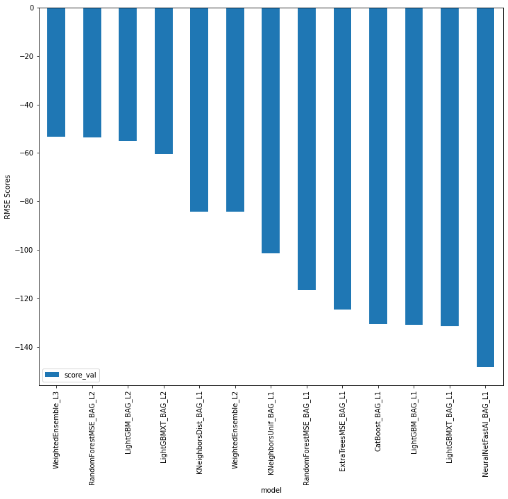

```python
# Plot model training performance  in a bar chart to compare performance
import matplotlib.pyplot as plt
leaderboard_df.plot(kind="bar", x="model", y="score_val", figsize=(12, 10))
plt.ylabel("RMSE Scores")
plt.show()
```

### Create predictions from test dataset

```python
predictions = predictor.predict(test)
predictions.head()
```

```
0    22.972031
1    42.110626
2    46.334229
3    48.938984
4    51.985825
Name: count, dtype: float32
```

#### NOTE: Kaggle will reject the submission if we don't set everything to be > 0.

```python
# Describe the `predictions` series to see if there are any negative values
predictions.describe()
```

```
count    6493.000000
mean      100.518578
std        89.859634
min         3.260016
25%        19.850754
50%        63.619995
75%       167.823883
max       366.492065
Name: count, dtype: float64
```

```python
# How many negative values do we have?
# Rechecking the predictions
# Count the number of negative values in the predictions series
negative_predictions_count = (predictions < 0).sum()
# Display the count of negative values
print("Number of negative Prediction values:", negative_predictions_count)
```

```
Number of negative Prediction values: 0
```

```python
# Set them to zero
predictions[predictions<0] = 0
```

### Set predictions to submission dataframe, save, and submit

```python
submission["count"] = predictions
submission.to_csv("submission.csv", index=False)
```

```python
!kaggle competitions submit -c bike-sharing-demand -f submission.csv -m "first raw submission"
```

```
Successfully submitted to Bike Sharing Demand
```

#### View submission via the command line or in the web browser under the competition's page - `My Submissions`

```python
!kaggle competitions submissions -c bike-sharing-demand | tail -n +1 | head -n 6
```

```
fileName                     date                 description                        status    publicScore  privateScore
---------------------------  -------------------  ---------------------------------  --------  -----------  ------------
submission.csv               2024-04-29 20:29:10  first raw submission               complete  1.80372      1.80372
submission.csv               2024-04-29 19:52:58  first raw submission               complete  1.7995       1.7995
submission_new_features.csv  2024-04-29 15:21:49  new features                       complete  0.49421      0.49421
submission_new_hpo.csv       2024-04-29 15:06:57  new features with hyperparameters  complete  0.53067      0.53067
```

#### Initial score of `1.80372`

## Step 4: Exploratory Data Analysis and Creating an additional feature

- Any additional feature will do, but a great suggestion would be to separate out the datetime into hour, day, or month parts.

```
array([[<Axes: title={'center': 'datetime'}>,
        <Axes: title={'center': 'season'}>,
        <Axes: title={'center': 'holiday'}>],
       [<Axes: title={'center': 'workingday'}>,
        <Axes: title={'center': 'weather'}>,
        <Axes: title={'center': 'temp'}>],
       [<Axes: title={'center': 'atemp'}>,
        <Axes: title={'center': 'humidity'}>,
        <Axes: title={'center': 'windspeed'}>],
       [<Axes: title={'center': 'casual'}>,
        <Axes: title={'center': 'registered'}>,
        <Axes: title={'center': 'count'}>]], dtype=object)
```

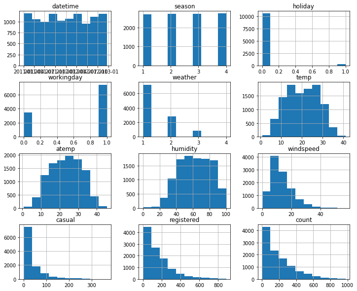

```python
# Create a histogram of all features to show the distribution of each one relative to the data. This is part of the exploritory data analysis
train.hist(figsize=(12, 10))
```

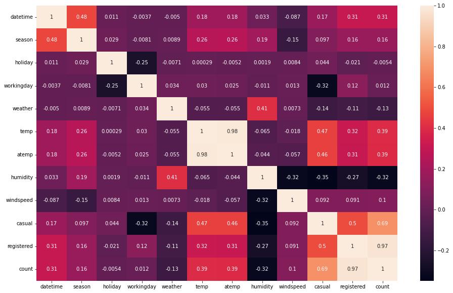

```python
import matplotlib.pyplot as plt
import seaborn as sns

plt.figure(figsize=(16,10))
sns.heatmap(train.corr(), annot=True)
plt.show()
```

```python
# create a new feature
# train : Extract year, month, day and hour into separate columns
train['year'] = train['datetime'].dt.year
train['month'] = train['datetime'].dt.month
train['day'] = train['datetime'].dt.day
train['hour'] = train['datetime'].dt.hour

# test : Extract year, month, day and hour into separate columns
test['year'] = test['datetime'].dt.year
test['month'] = test['datetime'].dt.month
test['day'] = test['datetime'].dt.day
test['hour'] = test['datetime'].dt.hour

train.head()
```

|  | datetime | season | holiday | workingday | weather | temp | atemp | humidity | windspeed | casual | registered | count | year | month | day | hour |
| --- | --- | --- | --- | --- | --- | --- | --- | --- | --- | --- | --- | --- | --- | --- | --- | --- |
| 0 | 2011-01-01 00:00:00 | 1 | 0 | 0 | 1 | 9.84 | 14.395 | 81 | 0.0 | 3 | 13 | 16 | 2011 | 1 | 1 | 0 |
| 1 | 2011-01-01 01:00:00 | 1 | 0 | 0 | 1 | 9.02 | 13.635 | 80 | 0.0 | 8 | 32 | 40 | 2011 | 1 | 1 | 1 |
| 2 | 2011-01-01 02:00:00 | 1 | 0 | 0 | 1 | 9.02 | 13.635 | 80 | 0.0 | 5 | 27 | 32 | 2011 | 1 | 1 | 2 |
| 3 | 2011-01-01 03:00:00 | 1 | 0 | 0 | 1 | 9.84 | 14.395 | 75 | 0.0 | 3 | 10 | 13 | 2011 | 1 | 1 | 3 |
| 4 | 2011-01-01 04:00:00 | 1 | 0 | 0 | 1 | 9.84 | 14.395 | 75 | 0.0 | 0 | 1 | 1 | 2011 | 1 | 1 | 4 |

```python
# now can drop datetime column. from train and test datasets
train.drop('datetime',axis=1,inplace=True)
test.drop('datetime',axis=1,inplace=True)
```

```python
# now can drop feature 'atemp' from train and test datasets
train.drop(["atemp"], axis=1, inplace=True)
test.drop(["atemp"], axis=1, inplace=True)
```

## Make category types for these so models know they are not just numbers

- AutoGluon originally sees these as ints, but in reality they are int representations of a category.
- Setting the dtype to category will classify these as categories in AutoGluon.

```python
# Change weather & season columns to a category
train["season"] = train["season"].astype("category")
train["weather"] = train["weather"].astype("category")
# we can see type of features with this info
train.info()
```

```
<class 'pandas.core.frame.DataFrame'>
RangeIndex: 10886 entries, 0 to 10885
Data columns (total 14 columns):
 #   Column      Non-Null Count  Dtype
---  ------      --------------  -----
 0   season      10886 non-null  category
 1   holiday     10886 non-null  int64
 2   workingday  10886 non-null  int64
 3   weather     10886 non-null  category
 4   temp        10886 non-null  float64
 5   humidity    10886 non-null  int64
 6   windspeed   10886 non-null  float64
 7   casual      10886 non-null  int64
 8   registered  10886 non-null  int64
 9   count       10886 non-null  int64
 10  year        10886 non-null  int32
 11  month       10886 non-null  int32
 12  day         10886 non-null  int32
 13  hour        10886 non-null  int32
dtypes: category(2), float64(2), int32(4), int64(6)
memory usage: 872.3 KB
```

```python
test["season"] = test["season"].astype("category")
test["weather"] = test["weather"].astype("category")

# we can see type of features with this info
test.info()
```

```
<class 'pandas.core.frame.DataFrame'>
RangeIndex: 6493 entries, 0 to 6492
Data columns (total 11 columns):
 #   Column      Non-Null Count  Dtype
---  ------      --------------  -----
 0   season      6493 non-null   category
 1   holiday     6493 non-null   int64
 2   workingday  6493 non-null   int64
 3   weather     6493 non-null   category
 4   temp        6493 non-null   float64
 5   humidity    6493 non-null   int64
 6   windspeed   6493 non-null   float64
 7   year        6493 non-null   int32
 8   month       6493 non-null   int32
 9   day         6493 non-null   int32
 10  hour        6493 non-null   int32
dtypes: category(2), float64(2), int32(4), int64(3)
memory usage: 368.3 KB
```

```python
# One hot encode the weather category to have individual features. Prefix with `weather`
weather_one_hot_train = pd.get_dummies(train.weather, prefix="weather")
# Add the one hot encoded values back to the df
train[weather_one_hot_train.columns.tolist()] = weather_one_hot_train

# One hot encode the season category to have individual features. Prefix with `season`
season_one_hot_train = pd.get_dummies(train.season, prefix="season")
# Add the one hot encoded values back to the df
train[season_one_hot_train.columns.tolist()] = season_one_hot_train

# # # now can drop weather and season.
train.drop(['season','weather'],inplace=True,axis=1)

# View are new feature
train.head()
```

|  | holiday | workingday | temp | humidity | windspeed | casual | registered | count | year | month | day | hour | weather_1 | weather_2 | weather_3 | weather_4 | season_1 | season_2 | season_3 | season_4 |
| --- | --- | --- | --- | --- | --- | --- | --- | --- | --- | --- | --- | --- | --- | --- | --- | --- | --- | --- | --- | --- |
| 0 | 0 | 0 | 9.84 | 81 | 0.0 | 3 | 13 | 16 | 2011 | 1 | 1 | 0 | True | False | False | False | True | False | False | False |
| 1 | 0 | 0 | 9.02 | 80 | 0.0 | 8 | 32 | 40 | 2011 | 1 | 1 | 1 | True | False | False | False | True | False | False | False |
| 2 | 0 | 0 | 9.02 | 80 | 0.0 | 5 | 27 | 32 | 2011 | 1 | 1 | 2 | True | False | False | False | True | False | False | False |
| 3 | 0 | 0 | 9.84 | 75 | 0.0 | 3 | 10 | 13 | 2011 | 1 | 1 | 3 | True | False | False | False | True | False | False | False |
| 4 | 0 | 0 | 9.84 | 75 | 0.0 | 0 | 1 | 1 | 2011 | 1 | 1 | 4 | True | False | False | False | True | False | False | False |

```python
# for test
# One hot encode the weather category to have individual features. Prefix with `weather`
weather_one_hot_test = pd.get_dummies(test.weather, prefix="weather")
# Add the one hot encoded values back to the df
test[weather_one_hot_test.columns.tolist()] = weather_one_hot_test

# One hot encode the season category to have individual features. Prefix with `season`
season_one_hot_test = pd.get_dummies(test.season, prefix="season")
# Add the one hot encoded values back to the df
test[season_one_hot_test.columns.tolist()] = season_one_hot_test

# # # now can drop weather and season.
test.drop(['season','weather'],inplace=True,axis=1)

# View are new feature
test.head()
```

|  | holiday | workingday | temp | humidity | windspeed | year | month | day | hour | weather_1 | weather_2 | weather_3 | weather_4 | season_1 | season_2 | season_3 | season_4 |
| --- | --- | --- | --- | --- | --- | --- | --- | --- | --- | --- | --- | --- | --- | --- | --- | --- | --- |
| 0 | 0 | 1 | 10.66 | 56 | 26.0027 | 2011 | 1 | 20 | 0 | True | False | False | False | True | False | False | False |
| 1 | 0 | 1 | 10.66 | 56 | 0.0000 | 2011 | 1 | 20 | 1 | True | False | False | False | True | False | False | False |
| 2 | 0 | 1 | 10.66 | 56 | 0.0000 | 2011 | 1 | 20 | 2 | True | False | False | False | True | False | False | False |
| 3 | 0 | 1 | 10.66 | 56 | 11.0014 | 2011 | 1 | 20 | 3 | True | False | False | False | True | False | False | False |
| 4 | 0 | 1 | 10.66 | 56 | 11.0014 | 2011 | 1 | 20 | 4 | True | False | False | False | True | False | False | False |

```
array([[<Axes: title={'center': 'holiday'}>,
        <Axes: title={'center': 'workingday'}>,
        <Axes: title={'center': 'temp'}>],
       [<Axes: title={'center': 'humidity'}>,
        <Axes: title={'center': 'windspeed'}>,
        <Axes: title={'center': 'casual'}>],
       [<Axes: title={'center': 'registered'}>,
        <Axes: title={'center': 'count'}>,
        <Axes: title={'center': 'year'}>],
       [<Axes: title={'center': 'month'}>,
        <Axes: title={'center': 'day'}>,
        <Axes: title={'center': 'hour'}>]], dtype=object)
```

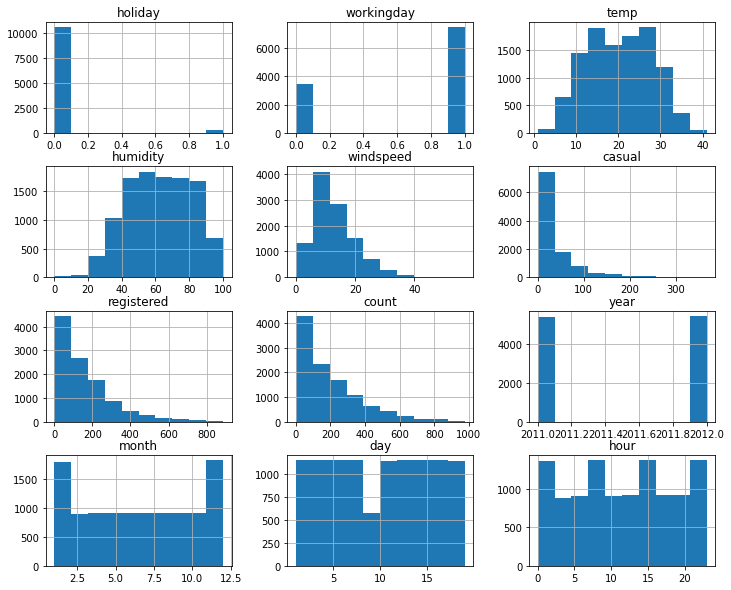

```python
# View histogram of all features again now with the hour feature
train.hist(figsize=(12, 10))
```

## Step 5: Rerun the model with the same settings as before, just with more features

```python
# Define the label column
label = "count"
# Define the columns to ignore
ignored_columns = ["casual", "registered"]
# Set up the time limit
time_limit = 600  # 10 minutes
# Define the metric
metric = 'root_mean_squared_error'
# Set the preset to 'best_quality'
preset = 'best_quality'

# Create and fit the predictor
predictor_new_features = TabularPredictor(label=label,
                             problem_type= 'regression',
                             eval_metric=metric,
                             learner_kwargs={'ignored_columns': ignored_columns}).fit(
                                                                           train_data = train,
                                                                           time_limit=time_limit,
                                                                           presets=preset)
```

[output not shown]

[output cut: 87 more lines]

```
	Fitting 8 child models (S1F1 - S1F8) | Fitting with ParallelLocalFoldFittingStrategy (2 workers, per: cpus=1, gpus=0, memory=0.81%)
	-36.3687	 = Validation score   (-root_mean_squared_error)
	33.68s	 = Training   runtime
	0.04s	 = Validation runtime
Fitting model: ExtraTreesMSE_BAG_L2 ... Training model for up to 13.39s of the 13.3s of remaining time.
	-36.1867	 = Validation score   (-root_mean_squared_error)
	14.05s	 = Training   runtime
	0.63s	 = Validation runtime
Fitting model: WeightedEnsemble_L3 ... Training model for up to 360.0s of the -6.65s of remaining time.
	Ensemble Weights: {'ExtraTreesMSE_BAG_L2': 0.32, 'LightGBMXT_BAG_L1': 0.24, 'CatBoost_BAG_L2': 0.16, 'CatBoost_BAG_L1': 0.12, 'RandomForestMSE_BAG_L2': 0.08, 'LightGBM_BAG_L1': 0.04, 'RandomForestMSE_BAG_L1': 0.04}
	-35.7653	 = Validation score   (-root_mean_squared_error)
	0.09s	 = Training   runtime
	0.0s	 = Validation runtime
AutoGluon training complete, total runtime = 408.99s ... Best model: "WeightedEnsemble_L3"
TabularPredictor saved. To load, use: predictor = TabularPredictor.load("AutogluonModels/ag-20240429_204327")
```

```python
predictor_new_features.fit_summary()
```

```
*** Summary of fit() ***
Estimated performance of each model:
                     model   score_val              eval_metric  pred_time_val    fit_time  pred_time_val_marginal  fit_time_marginal  stack_level  can_infer  fit_order
0      WeightedEnsemble_L3  -35.765306  root_mean_squared_error      27.780819  335.449701                0.001726           0.085485            3       True         14
1      WeightedEnsemble_L2  -36.057003  root_mean_squared_error      26.126665  249.306532                0.001567           0.041533            2       True          8
2     ExtraTreesMSE_BAG_L2  -36.186703  root_mean_squared_error      27.103677  263.403510                0.631687          14.054360            2       True         13
3          CatBoost_BAG_L2  -36.368740  root_mean_squared_error      26.515263  283.032275                0.043273          33.683125            2       True         12
4          LightGBM_BAG_L2  -36.573234  root_mean_squared_error      26.565710  263.763186                0.093720          14.414036            2       True         10
5   RandomForestMSE_BAG_L2  -36.733899  root_mean_squared_error      27.104132  287.626731                0.632143          38.277581            2       True         11
6        LightGBMXT_BAG_L2  -37.209124  root_mean_squared_error      26.689973  266.400388                0.217984          17.051238            2       True          9
7        LightGBMXT_BAG_L1  -37.558870  root_mean_squared_error      21.113935   82.279452               21.113935          82.279452            1       True          3
8          CatBoost_BAG_L1  -37.625980  root_mean_squared_error       0.093466  112.195605                0.093466         112.195605            1       True          6
9          LightGBM_BAG_L1  -37.938118  root_mean_squared_error       3.559265   32.042574                3.559265          32.042574            1       True          4
10    ExtraTreesMSE_BAG_L1  -41.368761  root_mean_squared_error       0.694399    8.898690                0.694399           8.898690            1       True          7
11  RandomForestMSE_BAG_L1  -42.335150  root_mean_squared_error       0.664032   13.848678                0.664032          13.848678            1       True          5
12   KNeighborsDist_BAG_L1 -118.597890  root_mean_squared_error       0.193930    0.036741                0.193930           0.036741            1       True          2
13   KNeighborsUnif_BAG_L1 -122.856549  root_mean_squared_error       0.152961    0.047409                0.152961           0.047409            1       True          1
Number of models trained: 14
Types of models trained:
{'StackerEnsembleModel_KNN', 'StackerEnsembleModel_XT', 'StackerEnsembleModel_CatBoost', 'StackerEnsembleModel_LGB', 'StackerEnsembleModel_RF', 'WeightedEnsembleModel'}
Bagging used: True  (with 8 folds)
Multi-layer stack-ensembling used: True  (with 3 levels)
Feature Metadata (Processed):
(raw dtype, special dtypes):
('float', [])     :  2 | ['temp', 'windspeed']
('int', [])       :  4 | ['humidity', 'month', 'day', 'hour']
('int', ['bool']) : 11 | ['holiday', 'workingday', 'year', 'weather_1', 'weather_2', ...]
*** End of fit() summary ***
```

[output not shown]

[output cut: 127 more lines]

[output not shown]

```python
# Leaderboard dataframe
leaderboard_df_new = pd.DataFrame(predictor_new_features.leaderboard(silent=True))
leaderboard_df_new
```

|  | model | score_val | eval_metric | pred_time_val | fit_time | pred_time_val_marginal | fit_time_marginal | stack_level | can_infer | fit_order |
| --- | --- | --- | --- | --- | --- | --- | --- | --- | --- | --- |
| 0 | WeightedEnsemble_L3 | -35.765306 | root_mean_squared_error | 27.780819 | 335.449701 | 0.001726 | 0.085485 | 3 | True | 14 |
| 1 | WeightedEnsemble_L2 | -36.057003 | root_mean_squared_error | 26.126665 | 249.306532 | 0.001567 | 0.041533 | 2 | True | 8 |
| 2 | ExtraTreesMSE_BAG_L2 | -36.186703 | root_mean_squared_error | 27.103677 | 263.403510 | 0.631687 | 14.054360 | 2 | True | 13 |
| 3 | CatBoost_BAG_L2 | -36.368740 | root_mean_squared_error | 26.515263 | 283.032275 | 0.043273 | 33.683125 | 2 | True | 12 |
| 4 | LightGBM_BAG_L2 | -36.573234 | root_mean_squared_error | 26.565710 | 263.763186 | 0.093720 | 14.414036 | 2 | True | 10 |
| 5 | RandomForestMSE_BAG_L2 | -36.733899 | root_mean_squared_error | 27.104132 | 287.626731 | 0.632143 | 38.277581 | 2 | True | 11 |
| 6 | LightGBMXT_BAG_L2 | -37.209124 | root_mean_squared_error | 26.689973 | 266.400388 | 0.217984 | 17.051238 | 2 | True | 9 |
| 7 | LightGBMXT_BAG_L1 | -37.558870 | root_mean_squared_error | 21.113935 | 82.279452 | 21.113935 | 82.279452 | 1 | True | 3 |
| 8 | CatBoost_BAG_L1 | -37.625980 | root_mean_squared_error | 0.093466 | 112.195605 | 0.093466 | 112.195605 | 1 | True | 6 |
| 9 | LightGBM_BAG_L1 | -37.938118 | root_mean_squared_error | 3.559265 | 32.042574 | 3.559265 | 32.042574 | 1 | True | 4 |
| 10 | ExtraTreesMSE_BAG_L1 | -41.368761 | root_mean_squared_error | 0.694399 | 8.898690 | 0.694399 | 8.898690 | 1 | True | 7 |
| 11 | RandomForestMSE_BAG_L1 | -42.335150 | root_mean_squared_error | 0.664032 | 13.848678 | 0.664032 | 13.848678 | 1 | True | 5 |
| 12 | KNeighborsDist_BAG_L1 | -118.597890 | root_mean_squared_error | 0.193930 | 0.036741 | 0.193930 | 0.036741 | 1 | True | 2 |
| 13 | KNeighborsUnif_BAG_L1 | -122.856549 | root_mean_squared_error | 0.152961 | 0.047409 | 0.152961 | 0.047409 | 1 | True | 1 |

```python
predictor_new_features.model_best
```

```
'WeightedEnsemble_L3'
```

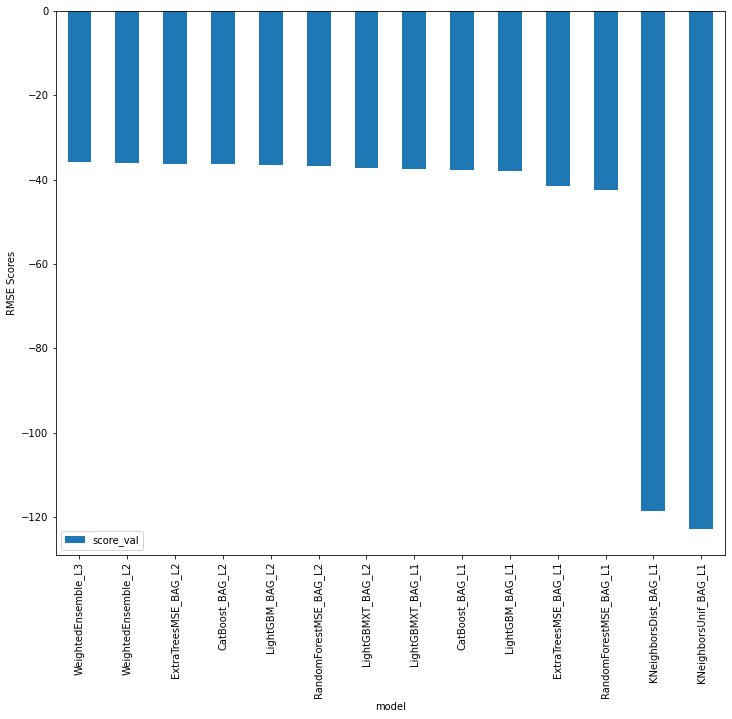

```python
# Plot model training performance  in a bar chart to compare performance
import matplotlib.pyplot as plt
leaderboard_df_new.plot(kind="bar", x="model", y="score_val", figsize=(12, 10))
plt.ylabel("RMSE Scores")
plt.show()
```

```python
predictions_new = predictor_new_features.predict(test)
predictions_new.head()
```

```
0    13.214513
1     4.012812
2     2.811649
3     3.301919
4     3.114549
Name: count, dtype: float32
```

```python
# Remember to set all negative values to zero
# Count the number of negative values in the predictions series
negative_predictions_count_new = (predictions_new < 0).sum()
# Display the count of negative values
print("Number of negative Prediction values:", negative_predictions_count_new)

# Set them to zero
predictions_new[predictions_new <0] = 0
```

```
Number of negative Prediction values: 27
```

```python
predictions_new.head()
```

```
0    13.214513
1     4.012812
2     2.811649
3     3.301919
4     3.114549
Name: count, dtype: float32
```

```python
# Describe the `predictions_new` series to see if there are any negative values
predictions_new.describe()
```

```
count    6493.000000
mean      189.523239
std       173.974045
min         0.000000
25%        45.758156
50%       145.037231
75%       284.296448
max       877.412109
Name: count, dtype: float64
```

```python
# Same submitting predictions
submission_new_features = submission
submission_new_features["count"] = predictions_new
submission_new_features.to_csv("submission_new_features.csv", index=False)
```

```python
!kaggle competitions submit -c bike-sharing-demand -f submission_new_features.csv -m "new features"
```

```
Successfully submitted to Bike Sharing Demand
```

```python
!kaggle competitions submissions -c bike-sharing-demand | tail -n +1 | head -n 6
```

```
fileName                     date                 description                        status    publicScore  privateScore
---------------------------  -------------------  ---------------------------------  --------  -----------  ------------
submission_new_features.csv  2024-04-29 20:54:59  new features                       complete  0.48139      0.48139
submission.csv               2024-04-29 20:29:10  first raw submission               complete  1.80372      1.80372
submission.csv               2024-04-29 19:52:58  first raw submission               complete  1.7995       1.7995
submission_new_features.csv  2024-04-29 15:21:49  new features                       complete  0.49421      0.49421
```

#### New Score of `0.48139`

## Step 6: Hyper parameter optimization

- There are many options for hyper parameter optimization.
- Options are to change the AutoGluon higher level parameters or the individual model hyperparameters.
- The hyperparameters of the models themselves that are in AutoGluon. Those need the `hyperparameter` and `hyperparameter_tune_kwargs` arguments.

```python
import autogluon.common as ag
## From autogluon documentation
# Define the label column
label = "count"
# Define the columns to ignore
ignored_columns = ["casual", "registered"]
# Set up the time limit
time_limit = 600  # 10 minutes
# Define the metric
metric = 'root_mean_squared_error'
# Set the preset to 'best_quality'
preset = 'best_quality'

# Test individual algorithm type GBM, XT, XGB, KNN and RF model types
# For NN models
nn_options = {  # specifies non-default hyperparameter values for neural network models
    'num_epochs': 10,  # number of training epochs (controls training time of NN models)
    'learning_rate': ag.space.Real(1e-4, 1e-2, default=5e-4, log=True),  # learning rate used in training (real-valued hyperparameter searched on log-scale)
    'activation': ag.space.Categorical('relu', 'softrelu', 'tanh'),  # activation function used in NN (categorical hyperparameter, default = first entry)
    'dropout_prob': ag.space.Real(0.0, 0.5, default=0.1),  # dropout probability (real-valued hyperparameter)
}

# For GBM
gbm_options = {  # specifies non-default hyperparameter values for lightGBM gradient boosted trees
    'num_boost_round': 100,  # number of boosting rounds (controls training time of GBM models)
    'num_leaves': ag.space.Int(lower=26, upper=66, default=36),  # number of leaves in trees (integer hyperparameter)
}


# XT Models
xt_options = {'criterion': 'squared_error', 'ag_args': {'name_suffix': 'MSE', 'problem_types': ['regression']}}

# Random Forest Models
rf_options = {'criterion': 'squared_error', 'ag_args': {'name_suffix': 'MSE', 'problem_types': ['regression']}}
# KNN
knn_options = [{'weights': 'uniform', 'ag_args': {'name_suffix': 'Uniform'}},
               {'weights': 'distance', 'ag_args': {'name_suffix': 'Distance'}}]  # default

hyperparameters = {  # hyperparameters of each model type
                   'GBM': gbm_options,
                   'NN_TORCH': nn_options,
                   'CAT': {'depth': ag.space.Int(lower=4, upper=7, default=6)},
                   'KNN': knn_options,
                   'XT': xt_options,
                   'XGB': {} ,
                   'RF': rf_options
                  }


num_trials = 5             # try at most 5 different hyperparameter configurations for each type of model
search_strategy = 'auto'  # to tune hyperparameters using random search routine with a local scheduler
scheduler = 'local'       # Local FIFO scheduler

hyperparameter_tune_kwargs = { # HPO is not performed unless hyperparameter_tune_kwargs is specified
                            'num_trials': num_trials,
                            'scheduler' : scheduler,
                            'searcher': search_strategy,
                        } # Refer to TabularPredictor.fit docstring for all valid values


predictor_new_hpo = TabularPredictor(label='count', problem_type='regression', eval_metric='root_mean_squared_error',
                                    learner_kwargs={'ignored_columns': ignored_columns}).fit(
                                                                         train_data=train,
                                                                         time_limit=time_limit,
                                                                         presets=preset,
                                                                         hyperparameters=hyperparameters,
                                                                         hyperparameter_tune_kwargs=hyperparameter_tune_kwargs )
```

[output not shown]

[output cut: 168 more lines]

[output not shown]

```python
predictor_new_hpo.fit_summary()
```

```
*** Summary of fit() ***
Estimated performance of each model:
                        model   score_val              eval_metric  pred_time_val    fit_time  pred_time_val_marginal  fit_time_marginal  stack_level  can_infer  fit_order
0         WeightedEnsemble_L3  -37.367292  root_mean_squared_error       0.003041  194.748982                0.001181           0.099364            3       True         16
1        ExtraTreesMSE_BAG_L2  -37.672295  root_mean_squared_error       0.001568  149.456325                0.000182          18.722191            2       True         14
2         WeightedEnsemble_L2  -37.832437  root_mean_squared_error       0.001692   98.406956                0.000899           0.057411            2       True          9
3          CatBoost_BAG_L2/T1  -37.948273  root_mean_squared_error       0.001677  175.927427                0.000292          45.193292            2       True         13
4      RandomForestMSE_BAG_L2  -38.268596  root_mean_squared_error       0.001575  176.863619                0.000189          46.129484            2       True         12
5          LightGBM_BAG_L2/T2  -38.342045  root_mean_squared_error       0.001523  147.452324                0.000138          16.718190            2       True         11
6          LightGBM_BAG_L2/T1  -38.370580  root_mean_squared_error       0.001524  150.013265                0.000139          19.279131            2       True         10
7           XGBoost_BAG_L2/T1  -38.438600  root_mean_squared_error       0.001589  158.485410                0.000203          27.751276            2       True         15
8           XGBoost_BAG_L1/T1  -39.358595  root_mean_squared_error       0.000148   30.915709                0.000148          30.915709            1       True          8
9          CatBoost_BAG_L1/T1  -39.988817  root_mean_squared_error       0.000125   38.863885                0.000125          38.863885            1       True          6
10       ExtraTreesMSE_BAG_L1  -41.368761  root_mean_squared_error       0.000240   10.821856                0.000240          10.821856            1       True          7
11     RandomForestMSE_BAG_L1  -42.335150  root_mean_squared_error       0.000279   17.748094                0.000279          17.748094            1       True          5
12         LightGBM_BAG_L1/T2  -43.100313  root_mean_squared_error       0.000149   17.018478                0.000149          17.018478            1       True          4
13         LightGBM_BAG_L1/T1  -44.861778  root_mean_squared_error       0.000146   14.720495                0.000146          14.720495            1       True          3
14  KNeighborsDistance_BAG_L1 -118.597890  root_mean_squared_error       0.000136    0.254222                0.000136           0.254222            1       True          2
15   KNeighborsUniform_BAG_L1 -122.856549  root_mean_squared_error       0.000161    0.391395                0.000161           0.391395            1       True          1
Number of models trained: 16
Types of models trained:
{'StackerEnsembleModel_KNN', 'StackerEnsembleModel_XT', 'StackerEnsembleModel_XGBoost', 'StackerEnsembleModel_CatBoost', 'StackerEnsembleModel_LGB', 'StackerEnsembleModel_RF', 'WeightedEnsembleModel'}
Bagging used: True  (with 8 folds)
Multi-layer stack-ensembling used: True  (with 3 levels)
Feature Metadata (Processed):
(raw dtype, special dtypes):
('float', [])     :  2 | ['temp', 'windspeed']
('int', [])       :  4 | ['humidity', 'month', 'day', 'hour']
('int', ['bool']) : 11 | ['holiday', 'workingday', 'year', 'weather_1', 'weather_2', ...]
*** End of fit() summary ***
```

[output not shown]

[output cut: 151 more lines]

[output not shown]

```python
# Leaderboard dataframe
leaderboard_df_new_hop = pd.DataFrame(predictor_new_hpo.leaderboard(silent=True))
leaderboard_df_new_hop
```

|  | model | score_val | eval_metric | pred_time_val | fit_time | pred_time_val_marginal | fit_time_marginal | stack_level | can_infer | fit_order |
| --- | --- | --- | --- | --- | --- | --- | --- | --- | --- | --- |
| 0 | WeightedEnsemble_L3 | -37.367292 | root_mean_squared_error | 0.003041 | 194.748982 | 0.001181 | 0.099364 | 3 | True | 16 |
| 1 | ExtraTreesMSE_BAG_L2 | -37.672295 | root_mean_squared_error | 0.001568 | 149.456325 | 0.000182 | 18.722191 | 2 | True | 14 |
| 2 | WeightedEnsemble_L2 | -37.832437 | root_mean_squared_error | 0.001692 | 98.406956 | 0.000899 | 0.057411 | 2 | True | 9 |
| 3 | CatBoost_BAG_L2/T1 | -37.948273 | root_mean_squared_error | 0.001677 | 175.927427 | 0.000292 | 45.193292 | 2 | True | 13 |
| 4 | RandomForestMSE_BAG_L2 | -38.268596 | root_mean_squared_error | 0.001575 | 176.863619 | 0.000189 | 46.129484 | 2 | True | 12 |
| 5 | LightGBM_BAG_L2/T2 | -38.342045 | root_mean_squared_error | 0.001523 | 147.452324 | 0.000138 | 16.718190 | 2 | True | 11 |
| 6 | LightGBM_BAG_L2/T1 | -38.370580 | root_mean_squared_error | 0.001524 | 150.013265 | 0.000139 | 19.279131 | 2 | True | 10 |
| 7 | XGBoost_BAG_L2/T1 | -38.438600 | root_mean_squared_error | 0.001589 | 158.485410 | 0.000203 | 27.751276 | 2 | True | 15 |
| 8 | XGBoost_BAG_L1/T1 | -39.358595 | root_mean_squared_error | 0.000148 | 30.915709 | 0.000148 | 30.915709 | 1 | True | 8 |
| 9 | CatBoost_BAG_L1/T1 | -39.988817 | root_mean_squared_error | 0.000125 | 38.863885 | 0.000125 | 38.863885 | 1 | True | 6 |
| 10 | ExtraTreesMSE_BAG_L1 | -41.368761 | root_mean_squared_error | 0.000240 | 10.821856 | 0.000240 | 10.821856 | 1 | True | 7 |
| 11 | RandomForestMSE_BAG_L1 | -42.335150 | root_mean_squared_error | 0.000279 | 17.748094 | 0.000279 | 17.748094 | 1 | True | 5 |
| 12 | LightGBM_BAG_L1/T2 | -43.100313 | root_mean_squared_error | 0.000149 | 17.018478 | 0.000149 | 17.018478 | 1 | True | 4 |
| 13 | LightGBM_BAG_L1/T1 | -44.861778 | root_mean_squared_error | 0.000146 | 14.720495 | 0.000146 | 14.720495 | 1 | True | 3 |
| 14 | KNeighborsDistance_BAG_L1 | -118.597890 | root_mean_squared_error | 0.000136 | 0.254222 | 0.000136 | 0.254222 | 1 | True | 2 |
| 15 | KNeighborsUniform_BAG_L1 | -122.856549 | root_mean_squared_error | 0.000161 | 0.391395 | 0.000161 | 0.391395 | 1 | True | 1 |